# Preventing Alcohol-exposed Pregnancy

Am J of Prev Med. 2007 Apr;32(4):360

[pubmed link](http://www.ncbi.nlm.nih.gov/pubmed/17218187)

# Epidemiology

**Non-pregnant** - 52 % alcohol  
- 15% binge  
MMWR. Alcohol Use and Binge Drinking Among Women of

Childbearing Age — United States,2006-2010(CDC)

# Epidemiology

Among **pregnant**, highest prevalence of prenatal alcohol use: - age between 35 and 44 years (14.3 percent), - college graduate, employed, white (~10.0 percent),

**Employed and unmarried** pregnant women  
- 2-3 x more likely binge drinking than the unemployed and married.  
MMWR. Alcohol Use and Binge Drinking Among Women of

Childbearing Age — United States, 2006-2010(CDC)

# Epidemiology

**National Birth Defects Prevention Study(4088 women)** who delivered live born infants without birth defects between 1997 and 2002 - 30.3 percent consumed alcohol at some time during pregnancy, - of whom 8.3 % binge drinking (at least four drinks on one occasion)  
Alcohol consumption by women before and during pregnancy.Ethen MK et al, National

Birth Defects Prevention. Matern Child Health J.2009;13(2):274.

==========================================================

**Epidemiology**

Many of these women at risk for an alcohol- exposed pregnancy - if sexually active and not using contraceptives.  
- Pregnancy Risk Assessment Monitoring System (PRAMS) survey  
(CDC 2004) - 50 % alcohol in the three months prior pregnancy  
D’Angelo et al MMWR Surveill Summ.2007;56(10):1 Preconception and interconception

Health status of women who recently gave birth to a live-born infant–PRAMS

============================================================== **Epidemiology**

Alcohol consumption – negative effects on fetus throughout  
pregnancy - stillbirths  
- Fetal Alcohol Spectrum Disorders -physical, mental, behavioral, and  
cognitive effects associated with in utero alcohol exposure  
Moderate alcohol intake during pregnancy and the risk of stillbirth and death

in the first year of life. Kesmodel U et al. Am J Epidemiol 2002;155(4):305.

==============================================================

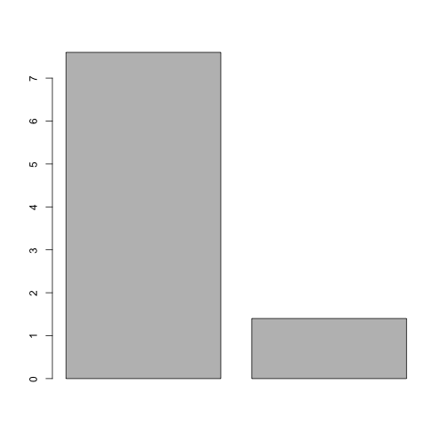

================================================================